mudanças climáticas e inadimplência

# SARIMAX: dinâmica temporal e exposição climática

Brasil | 2013–2024 | análise exploratória

## Objetivo e metodologia

A inadimplência nacional é calculada como 100 × soma da carteira inadimplente / soma da carteira ativa, conforme auditoria anterior. A entrada é a série nacional já publicada no repositório. y = 100×Δlog(I); x = Δlog(1+D). As diferenças foram feitas uma única vez fora do modelo e, portanto, d=D=0. A escolha entre termos sazonais AR/MA permanece empírica. Não se aplica outra diferenciação interna.

Comparamos SARIMA sem exógenas e SARIMAX com uma exposição e um lag por vez. A grade é deliberadamente pequena; primeiro exigimos Ljung–Box (6/12) favorável no baseline, quando existe candidato, depois usamos BIC. As inferências após seleção são exploratórias. Selecionar um lag isolado não estima efeito acumulado.

## Séries nacionais

São 144 meses (jan/2013–dez/2024). O total climático usa COBRADE 12/13/14; categorias por tipologia são publicadas na série agregada. Grupos COBRADE exatos não podem ser reconstituídos sem os registros brutos, que não estão versionados.

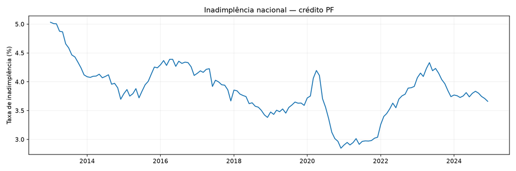

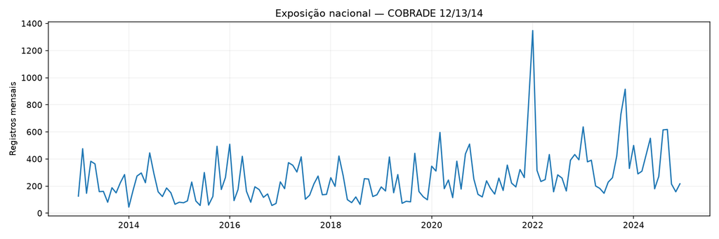

## ADF e KPSS

ADF: hipótese nula de raiz unitária. KPSS: hipótese nula de estacionariedade. Divergência entre testes não autoriza afirmar estacionariedade.

| periodo | variavel | transformacao | adf_p | kpss_p |
| --- | --- | --- | --- | --- |
| total | I | nível | 0.19576 | 0.01703 |
| total | I | primeira diferença | 0.02081 | 0.10000 |
| total | Clima \| Protocolos | nível | 0.50600 | 0.01000 |
| total | Clima \| Protocolos | primeira diferença | 0.00000 | 0.10000 |
| pré-pandemia | I | nível | 0.12208 | 0.01000 |
| pré-pandemia | I | primeira diferença | 0.34287 | 0.10000 |
| pré-pandemia | Clima \| Protocolos | nível | 0.00165 | 0.10000 |
| pré-pandemia | Clima \| Protocolos | primeira diferença | 0.00002 | 0.10000 |

## Seleção parcimoniosa

Treino até dez/2022; teste jan/2023–dez/2024. Pré-pandemia até jan/2020. Mesma amostra dentro de cada período, iniciada em mai/2013 devido às diferenças e ao lag 3. Entre modelos sem autocorrelação detectada pelo Ljung–Box (6/12), seleciona-se o menor BIC; se nenhum passar, o menor BIC é reportado com ressalva. Reportamos também AIC e convergência.

| periodo | categoria | lag | ordem | sazonal | n_treino | bic_treino | aic_treino | delta_bic_vs_baseline | diagnostico_ok |
| --- | --- | --- | --- | --- | --- | --- | --- | --- | --- |
| total | SARIMA | NaN | (1, 0, 1) | (1, 0, 0, 12) | 116 | 554.20827 | 540.44032 | 0.00000 | False |
| total | Clima \| Protocolos | 0.0 | (1, 0, 1) | (1, 0, 0, 12) | 116 | 555.82968 | 539.30814 | 1.62141 | False |
| total | Tipologia \| Alagamentos | 1.0 | (1, 0, 1) | (1, 0, 0, 12) | 116 | 556.76534 | 540.24380 | 2.55707 | False |
| total | Tipologia \| Chuvas Intensas | 1.0 | (1, 0, 1) | (1, 0, 0, 12) | 116 | 555.72983 | 539.20829 | 1.52156 | False |
| total | Tipologia \| Enxurradas | 1.0 | (1, 0, 1) | (1, 0, 0, 12) | 116 | 558.13231 | 541.61077 | 3.92404 | False |
| total | Tipologia \| Estiagem e Seca | 0.0 | (1, 0, 1) | (1, 0, 0, 12) | 116 | 555.43483 | 538.91329 | 1.22656 | False |
| total | Tipologia \| Granizo | 1.0 | (1, 0, 1) | (1, 0, 0, 12) | 116 | 556.67964 | 540.15810 | 2.47137 | False |
| total | Tipologia \| Incêndio Florestal | 3.0 | (1, 0, 1) | (1, 0, 0, 12) | 116 | 554.25453 | 537.73299 | 0.04626 | False |
| total | Tipologia \| Inundações | 0.0 | (1, 0, 1) | (1, 0, 0, 12) | 116 | 556.57994 | 540.05840 | 2.37167 | False |
| total | Tipologia \| Onda de Calor e Baixa Umidade | 0.0 | (1, 0, 1) | (1, 0, 0, 12) | 116 | 558.56717 | 542.04562 | 4.35890 | False |
| total | Tipologia \| Onda de Frio | 3.0 | (1, 0, 1) | (1, 0, 0, 12) | 116 | 558.62444 | 542.10290 | 4.41617 | False |
| total | Tipologia \| Tornado | 0.0 | (1, 0, 1) | (1, 0, 0, 12) | 116 | 558.73083 | 542.20929 | 4.52256 | False |
| total | Tipologia \| Vendavais e Ciclones | 3.0 | (1, 0, 1) | (1, 0, 0, 12) | 116 | 558.59515 | 542.07361 | 4.38689 | False |
| pré-pandemia | SARIMA | NaN | (1, 0, 0) | (1, 0, 0, 12) | 81 | 362.11829 | 352.54049 | 0.00000 | False |
| pré-pandemia | Clima \| Protocolos | 0.0 | (1, 0, 0) | (1, 0, 0, 12) | 81 | 362.92143 | 350.94918 | 0.80314 | False |
| pré-pandemia | Tipologia \| Alagamentos | 3.0 | (1, 0, 0) | (1, 0, 0, 12) | 81 | 364.97323 | 353.00099 | 2.85494 | False |
| pré-pandemia | Tipologia \| Chuvas Intensas | 1.0 | (1, 0, 0) | (1, 0, 0, 12) | 81 | 364.08879 | 352.11654 | 1.97049 | False |
| pré-pandemia | Tipologia \| Enxurradas | 3.0 | (1, 0, 0) | (1, 0, 0, 12) | 81 | 363.83024 | 351.85799 | 1.71194 | False |
| pré-pandemia | Tipologia \| Estiagem e Seca | 0.0 | (1, 0, 0) | (1, 0, 0, 12) | 81 | 364.55573 | 352.58349 | 2.43744 | False |
| pré-pandemia | Tipologia \| Granizo | 1.0 | (1, 0, 0) | (1, 0, 0, 12) | 81 | 365.08908 | 353.11683 | 2.97079 | False |
| pré-pandemia | Tipologia \| Incêndio Florestal | 0.0 | (1, 0, 0) | (1, 0, 0, 12) | 81 | 365.03251 | 353.06027 | 2.91422 | False |
| pré-pandemia | Tipologia \| Inundações | 0.0 | (1, 0, 0) | (1, 0, 0, 12) | 81 | 365.32750 | 353.35526 | 3.20921 | False |
| pré-pandemia | Tipologia \| Tornado | 3.0 | (1, 0, 0) | (1, 0, 0, 12) | 81 | 365.07041 | 353.09816 | 2.95212 | False |
| pré-pandemia | Tipologia \| Vendavais e Ciclones | 3.0 | (1, 0, 0) | (1, 0, 0, 12) | 81 | 365.11568 | 353.14343 | 2.99738 | False |

**Ver todas as especificações**

| periodo | categoria | lag | ordem | sazonal | bic | aic | status |
| --- | --- | --- | --- | --- | --- | --- | --- |
| total | SARIMA | NaN | (0, 0, 0) | (0, 0, 0, 12) | 573.94210 | 568.43492 | ok |
| total | SARIMA | NaN | (1, 0, 0) | (0, 0, 0, 12) | 573.91442 | 565.65365 | ok |
| total | SARIMA | NaN | (0, 0, 1) | (0, 0, 0, 12) | 574.90619 | 566.64542 | ok |
| total | SARIMA | NaN | (1, 0, 1) | (0, 0, 0, 12) | 574.56548 | 563.55112 | ok |
| total | SARIMA | NaN | (2, 0, 0) | (0, 0, 0, 12) | 575.77036 | 564.75600 | ok |
| total | SARIMA | NaN | (1, 0, 0) | (1, 0, 0, 12) | 554.43117 | 543.41681 | ok |
| total | SARIMA | NaN | (0, 0, 1) | (1, 0, 0, 12) | 559.75913 | 548.74477 | ok |
| total | SARIMA | NaN | (0, 0, 2) | (0, 0, 0, 12) | 577.85380 | 566.83944 | ok |
| total | SARIMA | NaN | (2, 0, 1) | (0, 0, 0, 12) | 578.44286 | 564.67491 | ok |
| total | SARIMA | NaN | (3, 0, 0) | (0, 0, 0, 12) | 573.82822 | 560.06027 | ok |
| total | SARIMA | NaN | (1, 0, 2) | (0, 0, 0, 12) | 577.10589 | 563.33794 | ok |
| total | SARIMA | NaN | (2, 0, 0) | (1, 0, 0, 12) | 555.84353 | 542.07558 | ok |
| total | SARIMA | NaN | (1, 0, 1) | (1, 0, 0, 12) | 554.20827 | 540.44032 | ok |
| total | SARIMA | NaN | (1, 0, 1) | (0, 0, 1, 12) | 562.88419 | 549.11624 | ok |
| total | SARIMA | NaN | (1, 0, 0) | (0, 0, 1, 12) | 563.46981 | 552.45545 | ok |
| total | Clima \| Protocolos | 0.0 | (1, 0, 1) | (1, 0, 0, 12) | 555.82968 | 539.30814 | ok |
| total | Clima \| Protocolos | 1.0 | (1, 0, 1) | (1, 0, 0, 12) | 558.95602 | 542.43448 | ok |
| total | Clima \| Protocolos | 3.0 | (1, 0, 1) | (1, 0, 0, 12) | 558.87292 | 542.35138 | ok |
| total | Tipologia \| Alagamentos | 0.0 | (1, 0, 1) | (1, 0, 0, 12) | 558.95730 | 542.43576 | ok |
| total | Tipologia \| Alagamentos | 1.0 | (1, 0, 1) | (1, 0, 0, 12) | 556.76534 | 540.24380 | ok |
| total | Tipologia \| Alagamentos | 3.0 | (1, 0, 1) | (1, 0, 0, 12) | 557.40254 | 540.88099 | ok |
| total | Tipologia \| Chuvas Intensas | 0.0 | (1, 0, 1) | (1, 0, 0, 12) | 558.64784 | 542.12630 | ok |
| total | Tipologia \| Chuvas Intensas | 1.0 | (1, 0, 1) | (1, 0, 0, 12) | 555.72983 | 539.20829 | ok |
| total | Tipologia \| Chuvas Intensas | 3.0 | (1, 0, 1) | (1, 0, 0, 12) | 558.94121 | 542.41967 | ok |
| total | Tipologia \| Enxurradas | 0.0 | (1, 0, 1) | (1, 0, 0, 12) | 558.34292 | 541.82137 | ok |
| total | Tipologia \| Enxurradas | 1.0 | (1, 0, 1) | (1, 0, 0, 12) | 558.13231 | 541.61077 | ok |
| total | Tipologia \| Enxurradas | 3.0 | (1, 0, 1) | (1, 0, 0, 12) | 558.91590 | 542.39436 | ok |
| total | Tipologia \| Estiagem e Seca | 0.0 | (1, 0, 1) | (1, 0, 0, 12) | 555.43483 | 538.91329 | ok |
| total | Tipologia \| Estiagem e Seca | 1.0 | (1, 0, 1) | (1, 0, 0, 12) | 558.43979 | 541.91825 | ok |
| total | Tipologia \| Estiagem e Seca | 3.0 | (1, 0, 1) | (1, 0, 0, 12) | 558.71148 | 542.18993 | ok |

[output cut: 62 more lines]

## Suporte das exposições

Triagem descritiva: pelo menos 18 meses positivos no treino e 30 registros. A baixa frequência impede inferência confiável para as categorias excluídas.

| periodo | categoria | meses_positivos | registros | estimavel |
| --- | --- | --- | --- | --- |
| total | Clima \| Protocolos | 116 | 27322 | True |
| total | Tipologia \| Alagamentos | 111 | 1160 | True |
| total | Tipologia \| Chuvas Intensas | 114 | 5058 | True |
| total | Tipologia \| Enxurradas | 111 | 2261 | True |
| total | Tipologia \| Estiagem e Seca | 116 | 12623 | True |
| total | Tipologia \| Granizo | 92 | 834 | True |
| total | Tipologia \| Incêndio Florestal | 87 | 1496 | True |
| total | Tipologia \| Inundações | 106 | 1723 | True |
| total | Tipologia \| Onda de Calor e Baixa Umidade | 29 | 56 | True |
| total | Tipologia \| Onda de Frio | 29 | 183 | True |
| total | Tipologia \| Tornado | 33 | 57 | True |
| total | Tipologia \| Vendavais e Ciclones | 115 | 1871 | True |
| pré-pandemia | Clima \| Protocolos | 81 | 16057 | True |
| pré-pandemia | Tipologia \| Alagamentos | 77 | 670 | True |
| pré-pandemia | Tipologia \| Chuvas Intensas | 79 | 2133 | True |
| pré-pandemia | Tipologia \| Enxurradas | 77 | 1759 | True |
| pré-pandemia | Tipologia \| Estiagem e Seca | 81 | 8461 | True |
| pré-pandemia | Tipologia \| Granizo | 61 | 504 | True |
| pré-pandemia | Tipologia \| Incêndio Florestal | 56 | 443 | True |
| pré-pandemia | Tipologia \| Inundações | 74 | 991 | True |
| pré-pandemia | Tipologia \| Onda de Calor e Baixa Umidade | 14 | 19 | False |
| pré-pandemia | Tipologia \| Onda de Frio | 13 | 59 | False |
| pré-pandemia | Tipologia \| Tornado | 25 | 41 | True |
| pré-pandemia | Tipologia \| Vendavais e Ciclones | 80 | 977 | True |

## Estimativas e inferência

Cada coeficiente é a associação condicional entre 100×Δlog(I) e uma unidade de Δlog(1+D) no lag indicado. Não são pontos percentuais da taxa I nem causalidade. P-valores usuais e BH não corrigem incerteza da seleção por BIC.

| periodo | categoria | lag | n | beta | erro_padrao | ic95_inf | ic95_sup | p | bic_treino | q_bh |
| --- | --- | --- | --- | --- | --- | --- | --- | --- | --- | --- |
| total | Clima \| Protocolos | 0 | 140 | 0.41744 | 0.24587 | -0.06446 | 0.89933 | 0.08955 | 555.82968 | 0.35819 |
| total | Tipologia \| Alagamentos | 1 | 140 | -0.32391 | 0.18798 | -0.69234 | 0.04451 | 0.08486 | 556.76534 | 0.35819 |
| total | Tipologia \| Chuvas Intensas | 1 | 140 | -0.27565 | 0.18659 | -0.64137 | 0.09006 | 0.13959 | 555.72983 | 0.36709 |
| total | Tipologia \| Enxurradas | 1 | 140 | -0.10579 | 0.14993 | -0.39965 | 0.18807 | 0.48044 | 558.13231 | 0.64602 |
| total | Tipologia \| Estiagem e Seca | 0 | 140 | 0.25839 | 0.15125 | -0.03806 | 0.55484 | 0.08758 | 555.43483 | 0.35819 |
| total | Tipologia \| Granizo | 1 | 140 | -0.21269 | 0.16444 | -0.53499 | 0.10960 | 0.19586 | 556.67964 | 0.39171 |
| total | Tipologia \| Incêndio Florestal | 3 | 140 | -0.27385 | 0.19162 | -0.64941 | 0.10171 | 0.15295 | 554.25453 | 0.36709 |
| total | Tipologia \| Inundações | 0 | 140 | 0.17229 | 0.15437 | -0.13028 | 0.47486 | 0.26441 | 556.57994 | 0.45327 |
| total | Tipologia \| Onda de Calor e Baixa Umidade | 0 | 140 | 0.10732 | 0.35070 | -0.58003 | 0.79467 | 0.75958 | 558.56717 | 0.82863 |
| total | Tipologia \| Onda de Frio | 3 | 140 | -0.03873 | 0.26714 | -0.56232 | 0.48485 | 0.88472 | 558.62444 | 0.88472 |
| total | Tipologia \| Tornado | 0 | 140 | -0.16917 | 0.24200 | -0.64347 | 0.30513 | 0.48451 | 558.73083 | 0.64602 |
| total | Tipologia \| Vendavais e Ciclones | 3 | 140 | 0.08882 | 0.19660 | -0.29650 | 0.47414 | 0.65142 | 558.59515 | 0.78171 |
| pré-pandemia | Clima \| Protocolos | 0 | 81 | 0.56255 | 0.28939 | -0.00465 | 1.12974 | 0.05191 | 362.92143 | 0.31659 |
| pré-pandemia | Tipologia \| Alagamentos | 3 | 81 | 0.36775 | 0.40591 | -0.42783 | 1.16332 | 0.36495 | 364.97323 | 0.36495 |
| pré-pandemia | Tipologia \| Chuvas Intensas | 1 | 81 | -0.30931 | 0.20919 | -0.71931 | 0.10069 | 0.13924 | 364.08879 | 0.31659 |
| pré-pandemia | Tipologia \| Enxurradas | 3 | 81 | 0.31041 | 0.19768 | -0.07705 | 0.69786 | 0.11637 | 363.83024 | 0.31659 |
| pré-pandemia | Tipologia \| Estiagem e Seca | 0 | 81 | 0.28115 | 0.20464 | -0.11993 | 0.68223 | 0.16948 | 364.55573 | 0.31659 |
| pré-pandemia | Tipologia \| Granizo | 1 | 81 | -0.21534 | 0.18989 | -0.58752 | 0.15685 | 0.25680 | 365.08908 | 0.31659 |
| pré-pandemia | Tipologia \| Incêndio Florestal | 0 | 81 | 0.27600 | 0.21933 | -0.15388 | 0.70589 | 0.20826 | 365.03251 | 0.31659 |
| pré-pandemia | Tipologia \| Inundações | 0 | 81 | 0.22297 | 0.20852 | -0.18572 | 0.63166 | 0.28493 | 365.32750 | 0.31659 |
| pré-pandemia | Tipologia \| Tornado | 3 | 81 | -0.37541 | 0.29738 | -0.95825 | 0.20744 | 0.20680 | 365.07041 | 0.31659 |
| pré-pandemia | Tipologia \| Vendavais e Ciclones | 3 | 81 | 0.30269 | 0.26633 | -0.21931 | 0.82468 | 0.25574 | 365.11568 | 0.31659 |

## Diagnósticos de resíduos

Ljung–Box verifica autocorrelação; ARCH avalia heterocedasticidade condicional; Jarque–Bera avalia normalidade. Valores p pequenos sinalizam ressalvas, sem que a normalidade isoladamente determine a validade do modelo.

| periodo | categoria | amostra | n | lb6_p | lb12_p | arch3_p | jarque_bera_p | convergiu |
| --- | --- | --- | --- | --- | --- | --- | --- | --- |
| total | SARIMA | treino | 116 | 0.00990 | 0.05195 | 0.02350 | 0.00000 | True |
| total | Clima \| Protocolos | treino | 116 | 0.00723 | 0.01705 | 0.01624 | 0.00000 | True |
| total | Clima \| Protocolos | amostra completa | 140 | 0.00260 | 0.00399 | 0.00592 | 0.00000 | True |
| total | Tipologia \| Alagamentos | treino | 116 | 0.01838 | 0.06427 | 0.03404 | 0.00000 | True |
| total | Tipologia \| Alagamentos | amostra completa | 140 | 0.00663 | 0.01797 | 0.01034 | 0.00000 | True |
| total | Tipologia \| Chuvas Intensas | treino | 116 | 0.00569 | 0.03133 | 0.03098 | 0.00000 | True |
| total | Tipologia \| Chuvas Intensas | amostra completa | 140 | 0.00149 | 0.00679 | 0.00918 | 0.00000 | True |
| total | Tipologia \| Enxurradas | treino | 116 | 0.00633 | 0.03302 | 0.00956 | 0.00000 | True |
| total | Tipologia \| Enxurradas | amostra completa | 140 | 0.00210 | 0.00852 | 0.00335 | 0.00000 | True |
| total | Tipologia \| Estiagem e Seca | treino | 116 | 0.01374 | 0.03768 | 0.06140 | 0.00000 | True |
| total | Tipologia \| Estiagem e Seca | amostra completa | 140 | 0.00478 | 0.00944 | 0.02132 | 0.00000 | True |
| total | Tipologia \| Granizo | treino | 116 | 0.01989 | 0.06835 | 0.04530 | 0.00000 | True |
| total | Tipologia \| Granizo | amostra completa | 140 | 0.00938 | 0.02447 | 0.01415 | 0.00000 | True |
| total | Tipologia \| Incêndio Florestal | treino | 116 | 0.00975 | 0.01926 | 0.02457 | 0.00058 | True |
| total | Tipologia \| Incêndio Florestal | amostra completa | 140 | 0.00383 | 0.00505 | 0.00822 | 0.00001 | True |
| total | Tipologia \| Inundações | treino | 116 | 0.00837 | 0.02846 | 0.02754 | 0.00000 | True |
| total | Tipologia \| Inundações | amostra completa | 140 | 0.00323 | 0.00998 | 0.00847 | 0.00000 | True |
| total | Tipologia \| Onda de Calor e Baixa Umidade | treino | 116 | 0.01391 | 0.06275 | 0.02823 | 0.00000 | True |
| total | Tipologia \| Onda de Calor e Baixa Umidade | amostra completa | 140 | 0.00448 | 0.01590 | 0.00850 | 0.00000 | True |
| total | Tipologia \| Onda de Frio | treino | 116 | 0.01098 | 0.05630 | 0.02813 | 0.00001 | True |
| total | Tipologia \| Onda de Frio | amostra completa | 140 | 0.00391 | 0.01531 | 0.00782 | 0.00000 | True |
| total | Tipologia \| Tornado | treino | 116 | 0.01030 | 0.05400 | 0.01801 | 0.00000 | True |
| total | Tipologia \| Tornado | amostra completa | 140 | 0.00385 | 0.01513 | 0.00460 | 0.00000 | True |
| total | Tipologia \| Vendavais e Ciclones | treino | 116 | 0.01386 | 0.05928 | 0.01749 | 0.00000 | True |
| total | Tipologia \| Vendavais e Ciclones | amostra completa | 140 | 0.00555 | 0.01793 | 0.00577 | 0.00000 | True |
| pré-pandemia | SARIMA | treino | 81 | 0.00240 | 0.03373 | 0.53007 | 0.54212 | True |
| pré-pandemia | Clima \| Protocolos | treino | 81 | 0.00039 | 0.00386 | 0.48357 | 0.34413 | True |
| pré-pandemia | Clima \| Protocolos | amostra completa | 81 | 0.00039 | 0.00386 | 0.48357 | 0.34413 | True |
| pré-pandemia | Tipologia \| Alagamentos | treino | 81 | 0.00083 | 0.01510 | 0.44863 | 0.47412 | True |
| pré-pandemia | Tipologia \| Alagamentos | amostra completa | 81 | 0.00083 | 0.01510 | 0.44863 | 0.47412 | True |
| pré-pandemia | Tipologia \| Chuvas Intensas | treino | 81 | 0.00086 | 0.01164 | 0.52914 | 0.71653 | True |
| pré-pandemia | Tipologia \| Chuvas Intensas | amostra completa | 81 | 0.00086 | 0.01164 | 0.52914 | 0.71653 | True |
| pré-pandemia | Tipologia \| Enxurradas | treino | 81 | 0.00174 | 0.02609 | 0.75774 | 0.50375 | True |
| pré-pandemia | Tipologia \| Enxurradas | amostra completa | 81 | 0.00174 | 0.02609 | 0.75774 | 0.50375 | True |
| pré-pandemia | Tipologia \| Estiagem e Seca | treino | 81 | 0.00097 | 0.01263 | 0.66164 | 0.17811 | True |
| pré-pandemia | Tipologia \| Estiagem e Seca | amostra completa | 81 | 0.00097 | 0.01263 | 0.66164 | 0.17811 | True |
| pré-pandemia | Tipologia \| Granizo | treino | 81 | 0.00343 | 0.03980 | 0.37353 | 0.66611 | True |
| pré-pandemia | Tipologia \| Granizo | amostra completa | 81 | 0.00343 | 0.03980 | 0.37353 | 0.66611 | True |
| pré-pandemia | Tipologia \| Incêndio Florestal | treino | 81 | 0.00159 | 0.02651 | 0.75437 | 0.32063 | True |
| pré-pandemia | Tipologia \| Incêndio Florestal | amostra completa | 81 | 0.00159 | 0.02651 | 0.75437 | 0.32063 | True |
| pré-pandemia | Tipologia \| Inundações | treino | 81 | 0.00218 | 0.02567 | 0.42167 | 0.82823 | True |
| pré-pandemia | Tipologia \| Inundações | amostra completa | 81 | 0.00218 | 0.02567 | 0.42167 | 0.82823 | True |
| pré-pandemia | Tipologia \| Tornado | treino | 81 | 0.00353 | 0.04506 | 0.48453 | 0.69796 | True |
| pré-pandemia | Tipologia \| Tornado | amostra completa | 81 | 0.00353 | 0.04506 | 0.48453 | 0.69796 | True |
| pré-pandemia | Tipologia \| Vendavais e Ciclones | treino | 81 | 0.00267 | 0.03360 | 0.64765 | 0.36124 | True |
| pré-pandemia | Tipologia \| Vendavais e Ciclones | amostra completa | 81 | 0.00267 | 0.03360 | 0.64765 | 0.36124 | True |

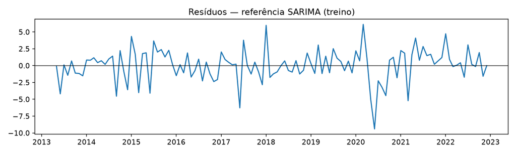

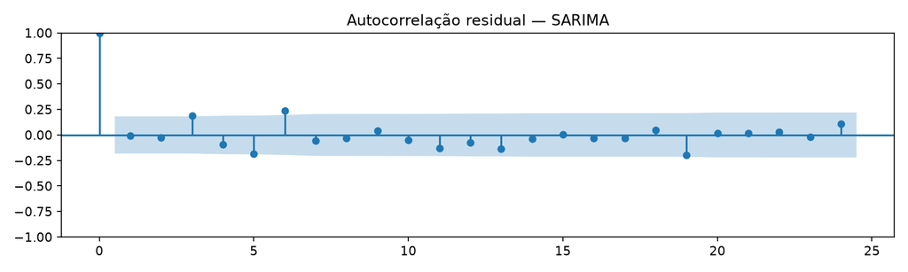

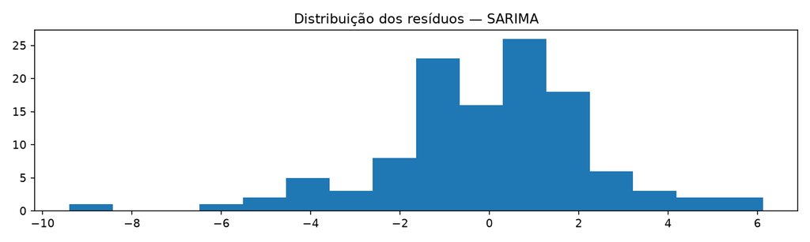

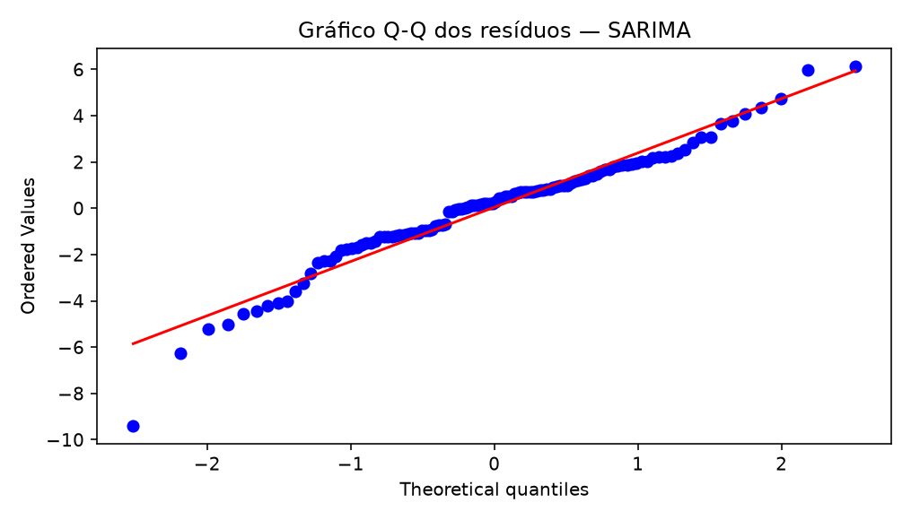

## Avaliação temporal

Previsões um passo à frente com atualização do estado e parâmetros fixos. Quando o regressor é contemporâneo, a previsão utiliza o desastre observado no mesmo mês: é condicional, e não uma previsão operacional ex ante. MAE/RMSE referem-se a 100×Δlog(I), não à taxa em pontos percentuais.

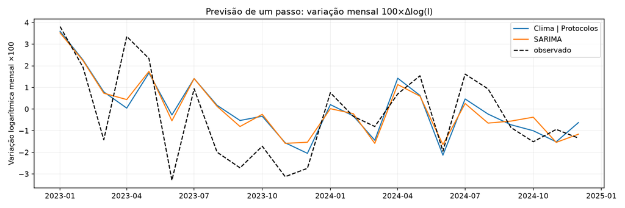

| categoria | lag | n_teste | mae | rmse | tipo |
| --- | --- | --- | --- | --- | --- |
| SARIMA | NaN | 24 | 1.09208 | 1.35482 | univariada |
| Clima \| Protocolos | 0.0 | 24 | 1.06278 | 1.38500 | condicional, D_t observado |
| Tipologia \| Alagamentos | 1.0 | 24 | 1.04570 | 1.35700 | lag conhecido no início do mês |
| Tipologia \| Chuvas Intensas | 1.0 | 24 | 0.99213 | 1.35895 | lag conhecido no início do mês |
| Tipologia \| Enxurradas | 1.0 | 24 | 1.04491 | 1.38165 | lag conhecido no início do mês |
| Tipologia \| Estiagem e Seca | 0.0 | 24 | 1.14836 | 1.43467 | condicional, D_t observado |
| Tipologia \| Granizo | 1.0 | 24 | 1.04976 | 1.32472 | lag conhecido no início do mês |
| Tipologia \| Incêndio Florestal | 3.0 | 24 | 1.27225 | 1.53892 | lag conhecido no início do mês |
| Tipologia \| Inundações | 0.0 | 24 | 1.16822 | 1.47233 | condicional, D_t observado |
| Tipologia \| Onda de Calor e Baixa Umidade | 0.0 | 24 | 1.11035 | 1.38597 | condicional, D_t observado |
| Tipologia \| Onda de Frio | 3.0 | 24 | 1.11173 | 1.39841 | lag conhecido no início do mês |
| Tipologia \| Tornado | 0.0 | 24 | 1.08502 | 1.33442 | condicional, D_t observado |
| Tipologia \| Vendavais e Ciclones | 3.0 | 24 | 1.09725 | 1.36409 | lag conhecido no início do mês |

## Conclusões e limitações

O BIC dos candidatos é comparável apenas na mesma amostra. Um BIC menor não prova causalidade nem melhora preditiva. Uma não rejeição da hipótese nula não comprova ausência de associação. Sem grupos COBRADE reconstruídos exatamente, a comparação por grupo está pendente dos registros brutos. Resultados pré-pandemia são exploratórios pelo tamanho da amostra. Diferença BIC (total climático − SARIMA) no treino: 1.621. Nenhum baseline testado apresentou p≥0,05 simultaneamente em Ljung–Box 6 e 12. Não se declara um modelo final adequado; estimativas são diagnósticas e exploratórias.

A análise é observacional. O SARIMAX nacional não substitui o painel estadual dos DLMs: não representa heterogeneidade entre UFs. A escolha de termos ARMA e regressoras condiciona os erros-padrão. A classificação Atlas é administrativa e inclui ressalvas de taxonomia.